# DATA 606 - Lab 7 - Inference for Numerical Data

Preston Peck

11/1/2021

# Inference for Numerical Data

https://htmlpreview.github.io/?https://github.com/jbryer/DATA606/blob/master/inst/labs/Lab7/Lab7_inf_for_numerical_data.html

```r
library(tidyverse)
library(openintro)
library(infer)
library(psych)
library(Rmisc)
library(DescTools)
```

```r
set.seed(37)

data('yrbss', package='openintro')
yrbss
```

```
## # A tibble: 13,583 × 13
##      age gender grade hispanic race    height weight helmet_12m text_while_driv…
##    <int> <chr>  <chr> <chr>    <chr>    <dbl>  <dbl> <chr>      <chr>
##  1    14 female 9     not      Black …  NA      NA   never      0
##  2    14 female 9     not      Black …  NA      NA   never      <NA>
##  3    15 female 9     hispanic Native…   1.73   84.4 never      30
##  4    15 female 9     not      Black …   1.6    55.8 never      0
##  5    15 female 9     not      Black …   1.5    46.7 did not r… did not drive
##  6    15 female 9     not      Black …   1.57   67.1 did not r… did not drive
##  7    15 female 9     not      Black …   1.65  132.  did not r… <NA>
##  8    14 male   9     not      Black …   1.88   71.2 never      <NA>
##  9    15 male   9     not      Black …   1.75   63.5 never      <NA>
## 10    15 male   10    not      Black …   1.37   97.1 did not r… <NA>
## # … with 13,573 more rows, and 4 more variables: physically_active_7d <int>,
## #   hours_tv_per_school_day <chr>, strength_training_7d <int>,
## #   school_night_hours_sleep <chr>
```

### Exercise 1

There are 13583 cases (rows)

```r
yrbss %>%
  glimpse
```

```
## Rows: 13,583
## Columns: 13
## $ age                      <int> 14, 14, 15, 15, 15, 15, 15, 14, 15, 15, 15, 1…
## $ gender                   <chr> "female", "female", "female", "female", "fema…
## $ grade                    <chr> "9", "9", "9", "9", "9", "9", "9", "9", "9", …
## $ hispanic                 <chr> "not", "not", "hispanic", "not", "not", "not"…
## $ race                     <chr> "Black or African American", "Black or Africa…
## $ height                   <dbl> NA, NA, 1.73, 1.60, 1.50, 1.57, 1.65, 1.88, 1…
## $ weight                   <dbl> NA, NA, 84.37, 55.79, 46.72, 67.13, 131.54, 7…
## $ helmet_12m               <chr> "never", "never", "never", "never", "did not …
## $ text_while_driving_30d   <chr> "0", NA, "30", "0", "did not drive", "did not…
## $ physically_active_7d     <int> 4, 2, 7, 0, 2, 1, 4, 4, 5, 0, 0, 0, 4, 7, 7, …
## $ hours_tv_per_school_day  <chr> "5+", "5+", "5+", "2", "3", "5+", "5+", "5+",…
## $ strength_training_7d     <int> 0, 0, 0, 0, 1, 0, 2, 0, 3, 0, 3, 0, 0, 7, 7, …
## $ school_night_hours_sleep <chr> "8", "6", "<5", "6", "9", "8", "9", "6", "<5"…
```

```r
yrbss %>%
  nrow
```

```
## [1] 13583
```

### Exercise 2

There are valid 12579 entries and 1004 NA’s

```r
yrbss$weight %>%
  describe
```

```
##    vars     n  mean   sd median trimmed  mad   min    max  range skew kurtosis
## X1    1 12579 67.91 16.9  64.41   66.03 14.8 29.94 180.99 151.05 1.25     2.28
##      se
## X1 0.15
```

```r
yrbss$weight %>%
  summary
```

```
##    Min. 1st Qu.  Median    Mean 3rd Qu.    Max.    NA's
##   29.94   56.25   64.41   67.91   76.20  180.99    1004
```

### Exercise 3

Those working out more than 2 days a week weight more, and that might be accredited to increased muscle mass

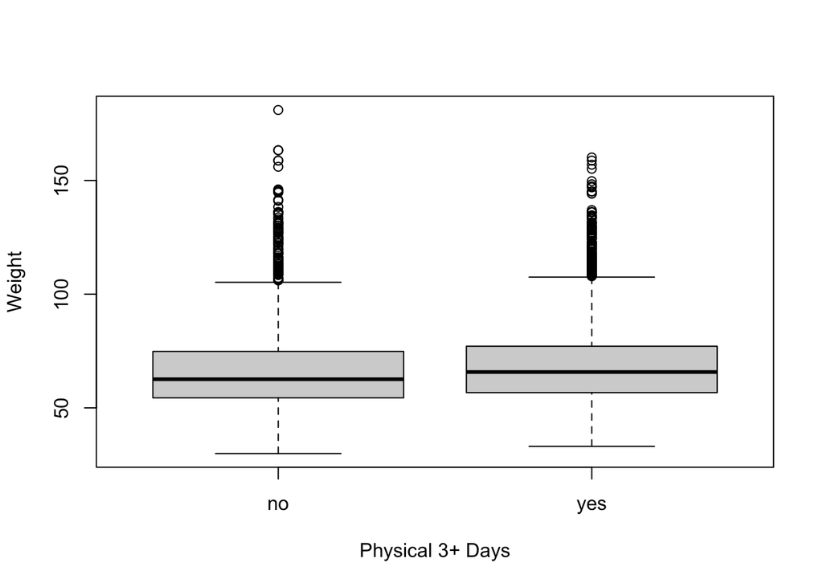

```r
yesLabel <- "yes"
noLabel <- "no"



yrbss <- yrbss %>%
  mutate(physical_3plus = ifelse(yrbss$physically_active_7d > 2, yesLabel, noLabel))

boxplot(yrbss$weight ~ yrbss$physical_3plus, ylab = "Weight", xlab = "Physical 3+ Days")
```

```r
no_physical_3plus <- (yrbss %>%
  filter(physical_3plus == noLabel))

no_physical_3plus$weight %>%
  summary
```

```
##    Min. 1st Qu.  Median    Mean 3rd Qu.    Max.    NA's
##   29.94   54.43   62.60   66.67   74.84  180.99     382
```

```r
no_physical_3plus$weight %>%
  describe
```

```
##    vars    n  mean    sd median trimmed   mad   min    max  range skew kurtosis
## X1    1 4022 66.67 17.64   62.6    64.5 14.13 29.94 180.99 151.05 1.41     2.88
##      se
## X1 0.28
```

```r
yes_physical_3plus <- (yrbss %>%
  filter(physical_3plus == yesLabel))

yes_physical_3plus$weight %>%
  summary
```

```
##    Min. 1st Qu.  Median    Mean 3rd Qu.    Max.    NA's
##   33.11   56.70   65.77   68.45   77.11  160.12     564
```

```r
yes_physical_3plus$weight %>%
  describe
```

```
##    vars    n  mean    sd median trimmed   mad   min    max  range skew kurtosis
## X1    1 8342 68.45 16.48  65.77   66.71 13.45 33.11 160.12 127.01 1.17     1.99
##      se
## X1 0.18
```

```r
yrbss %>%
  group_by(physical_3plus) %>%
  dplyr::summarise(mean_weight = mean(weight, na.rm = TRUE))
```

```
## # A tibble: 3 × 2
##   physical_3plus mean_weight
##   <chr>                <dbl>
## 1 no                    66.7
## 2 yes                   68.4
## 3 <NA>                  69.9
```

### Exercise 4

There are 3 conditions for interference: Random, Normal, Independence \ The sample is random ✓  
The sample skew is normal ?  
-> If the skew is not normal (right skew) or it has an unknown parent population, the sample size must be large (n ≥ 30) ✓  
The sample is independent (n ≤ 10% of population — 13583 / 4.9 million high school students from 1991-2019) ✓

```r
yrbss %>%
  group_by(physical_3plus) %>%
  filter(!is.na(weight)) %>%
  dplyr::count(physical_3plus)
```

```
## # A tibble: 3 × 2
## # Groups:   physical_3plus [3]
##   physical_3plus     n
##   <chr>          <int>
## 1 no              4022
## 2 yes             8342
## 3 <NA>             215
```

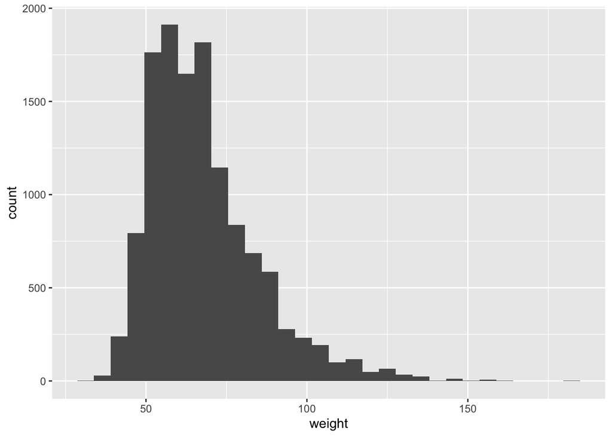

```r
ggplot(data = yrbss, aes(x = weight)) +
    geom_histogram()
```

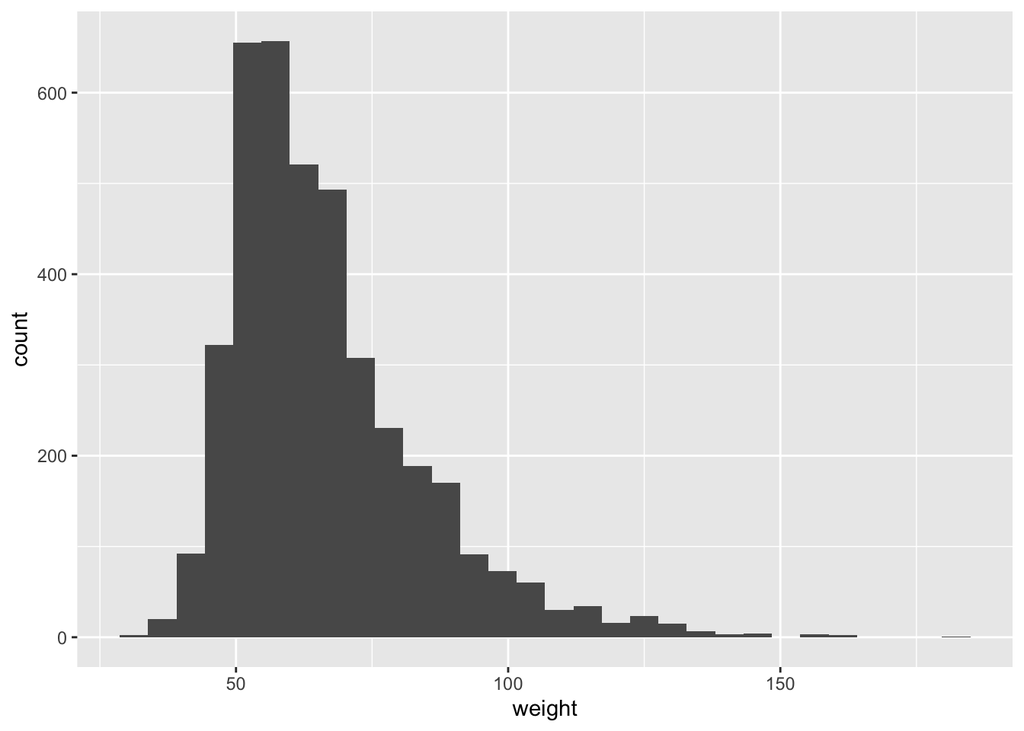

```r
ggplot(data = no_physical_3plus, aes(x = weight)) +
    geom_histogram()
```

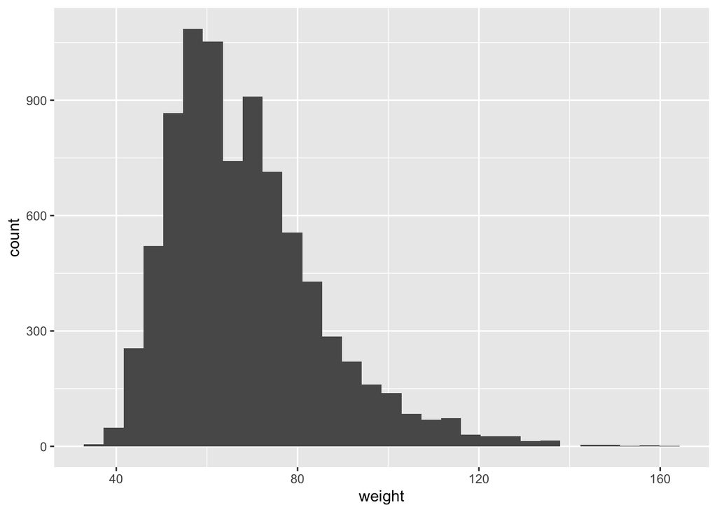

```r
ggplot(data = yes_physical_3plus, aes(x = weight)) +
    geom_histogram()
```

### Exercise 5

H0: There is no correlation between weight and number of days worked out in a week  
HA: There is a correlation between weight and number of days worked out in a week

### Exercise 6

No values are greater than obs_stat  
Since the p-value is less than 0.05, we can reject the null hypothesis

```r
obs_diff <- yrbss %>%
  specify(weight ~ physical_3plus) %>%
  calculate(stat = "diff in means", order = c("yes", "no"))
obs_diff
```

```
## Response: weight (numeric)
## Explanatory: physical_3plus (factor)
## # A tibble: 1 × 1
##    stat
##   <dbl>
## 1  1.77
```

```r
null_dist <- yrbss %>%
  specify(weight ~ physical_3plus) %>%
  hypothesize(null = "independence") %>%
  generate(reps = 1000, type = "permute") %>%
  calculate(stat = "diff in means", order = c("yes", "no"))
null_dist
```

```
## Response: weight (numeric)
## Explanatory: physical_3plus (factor)
## Null Hypothesis: independence
## # A tibble: 1,000 × 2
##    replicate    stat
##        <int>   <dbl>
##  1         1  0.420
##  2         2 -0.0761
##  3         3 -0.240
##  4         4  0.535
##  5         5  0.190
##  6         6 -0.287
##  7         7  0.349
##  8         8 -0.146
##  9         9 -0.475
## 10        10  0.762
## # … with 990 more rows
```

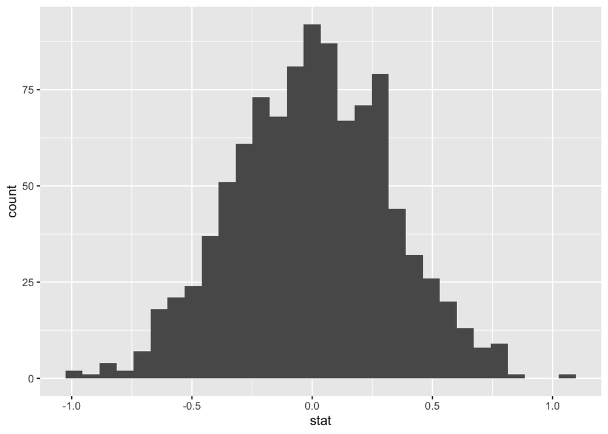

```r
ggplot(data = null_dist, aes(x = stat)) +
  geom_histogram()
```

```r
null_dist %>%
  get_p_value(obs_stat = obs_diff, direction = "two_sided")
```

```
## # A tibble: 1 × 1
##   p_value
##     <dbl>
## 1       0
```

### Exercise 7

We’re 95% sure the difference of averages of all weights of those who don’t work 3 days and greater and those that do falls somewhere between -2.424441 and -1.124728

```r
DATA606::inference(y = yrbss$weight,
                   x = yrbss$physical_3plus,
                   null = 0,
                   est = "mean",
                   type = "ht",
                   alternative = "twosided",
                   method = "theoretical")
```

```
## Response variable: numerical, Explanatory variable: categorical
## Difference between two means
## Summary statistics:
## n_no = 4022, mean_no = 66.6739, sd_no = 17.6381
## n_yes = 8342, mean_yes = 68.4485, sd_yes = 16.4783
```

```
## Observed difference between means (no-yes) = -1.7746
##
## H0: mu_no - mu_yes = 0
## HA: mu_no - mu_yes != 0
## Standard error = 0.332
## Test statistic: Z =  -5.353
## p-value =  0
```

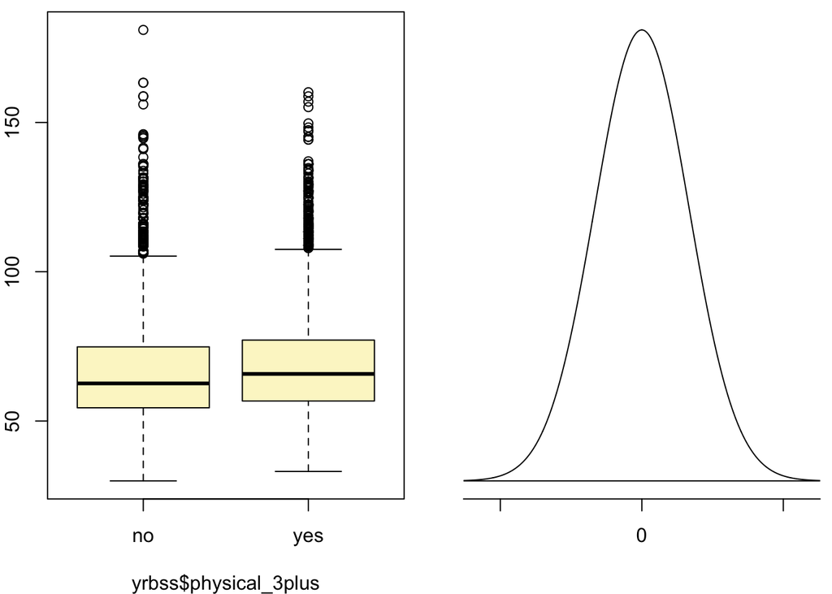

```r
oilabs::inference(y = weight,
                  x = physical_3plus,
                  data = yrbss,
                  null = 0,
                  statistic = "mean",
                  type = "ht",
                  alternative = "twosided",
                  method = "theoretical")
```

```
## Response variable: numerical
## Explanatory variable: categorical (2 levels)
## n_no = 4022, y_bar_no = 66.6739, s_no = 17.6381
## n_yes = 8342, y_bar_yes = 68.4485, s_yes = 16.4783
## H0: mu_no =  mu_yes
## HA: mu_no != mu_yes
## t = -5.353, df = 4021
## p_value = < 0.0001
```

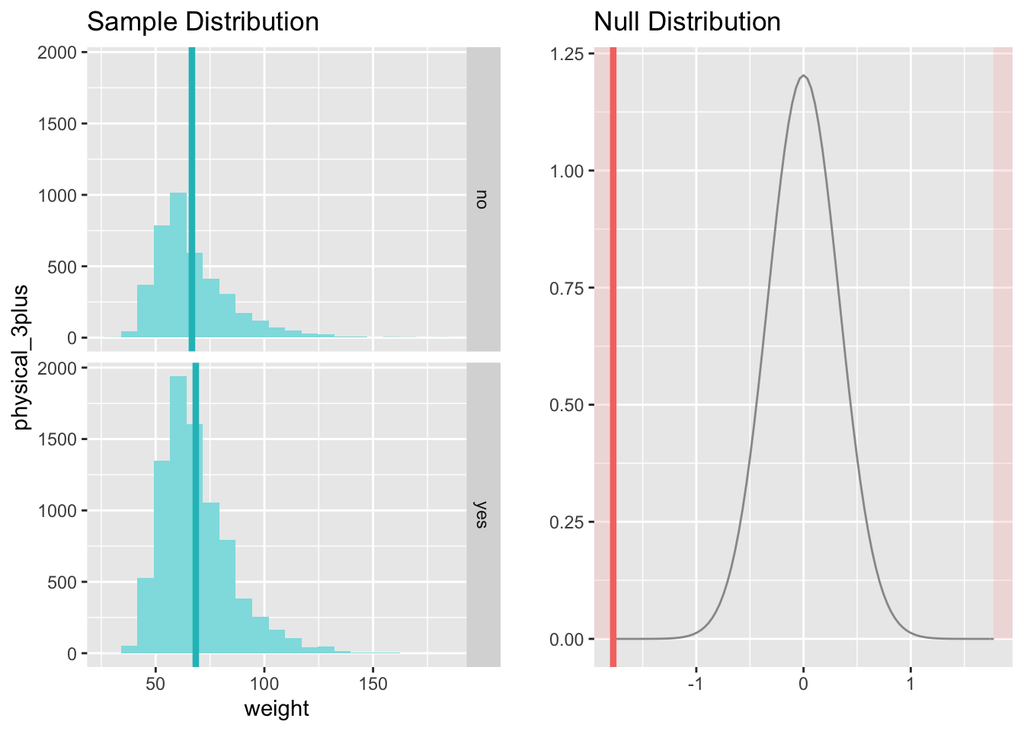

```r
t.test(data = yrbss, weight ~ physical_3plus)
```

```
##
##  Welch Two Sample t-test
##
## data:  weight by physical_3plus
## t = -5.353, df = 7478.8, p-value = 8.908e-08
## alternative hypothesis: true difference in means is not equal to 0
## 95 percent confidence interval:
##  -2.424441 -1.124728
## sample estimates:
##  mean in group no mean in group yes
##          66.67389          68.44847
```

```r
yes_physical_3plus$weight %>%
  t.test
```

```
##
##  One Sample t-test
##
## data:  .
## t = 379.39, df = 8341, p-value < 2.2e-16
## alternative hypothesis: true mean is not equal to 0
## 95 percent confidence interval:
##  68.09481 68.80213
## sample estimates:
## mean of x
##  68.44847
```

```r
no_physical_3plus$weight %>%
  t.test
```

```
##
##  One Sample t-test
##
## data:  .
## t = 239.73, df = 4021, p-value < 2.2e-16
## alternative hypothesis: true mean is not equal to 0
## 95 percent confidence interval:
##  66.12862 67.21915
## sample estimates:
## mean of x
##  66.67389
```

### Exercise 8

We’re 95% sure the average of all heights of those who work 3 days and greater and those that don’t falls somewhere between 1.689411 and 1.693071

```r
yrbss$height %>%
  summary
```

```
##    Min. 1st Qu.  Median    Mean 3rd Qu.    Max.    NA's
##   1.270   1.600   1.680   1.691   1.780   2.110    1004
```

```r
yrbss_heights <- yrbss %>%
  filter(!is.na(height))



physical_3plus_grouped <- yrbss_heights %>%
  group_by(physical_3plus)

physical_3plus_grouped
```

```
## # A tibble: 12,579 × 14
## # Groups:   physical_3plus [3]
##      age gender grade hispanic race    height weight helmet_12m text_while_driv…
##    <int> <chr>  <chr> <chr>    <chr>    <dbl>  <dbl> <chr>      <chr>
##  1    15 female 9     hispanic Native…   1.73   84.4 never      30
##  2    15 female 9     not      Black …   1.6    55.8 never      0
##  3    15 female 9     not      Black …   1.5    46.7 did not r… did not drive
##  4    15 female 9     not      Black …   1.57   67.1 did not r… did not drive
##  5    15 female 9     not      Black …   1.65  132.  did not r… <NA>
##  6    14 male   9     not      Black …   1.88   71.2 never      <NA>
##  7    15 male   9     not      Black …   1.75   63.5 never      <NA>
##  8    15 male   10    not      Black …   1.37   97.1 did not r… <NA>
##  9    15 female 9     not      Black …   1.68   69.8 did not r… 0
## 10    15 female 9     not      Black …   1.65   66.7 did not r… did not drive
## # … with 12,569 more rows, and 5 more variables: physically_active_7d <int>,
## #   hours_tv_per_school_day <chr>, strength_training_7d <int>,
## #   school_night_hours_sleep <chr>, physical_3plus <chr>
```

```r
physical_3plus_grouped_means <- physical_3plus_grouped %>%
  dplyr::summarise(mean(height))

physical_3plus_grouped_means
```

```
## # A tibble: 3 × 2
##   physical_3plus `mean(height)`
##   <chr>                   <dbl>
## 1 no                       1.67
## 2 yes                      1.70
## 3 <NA>                     1.71
```

```r
yrbss_mean <- mean(yrbss_heights$height)

yrbss_mean
```

```
## [1] 1.691241
```

```r
physical_3plus_grouped_counts <- physical_3plus_grouped %>%
  dplyr::count(physical_3plus)

physical_3plus_grouped_counts
```

```
## # A tibble: 3 × 2
## # Groups:   physical_3plus [3]
##   physical_3plus     n
##   <chr>          <int>
## 1 no              4022
## 2 yes             8342
## 3 <NA>             215
```

```r
yrbss_count <- nrow(yrbss_heights)

yrbss_count
```

```
## [1] 12579
```

```r
physical_3plus_grouped_sds <- physical_3plus_grouped %>%
  dplyr::summarise(sd(height))

physical_3plus_grouped_sds
```

```
## # A tibble: 3 × 2
##   physical_3plus `sd(height)`
##   <chr>                 <dbl>
## 1 no                    0.103
## 2 yes                   0.103
## 3 <NA>                  0.107
```

```r
yrbss_sd <- sd(yrbss_heights$height)

yrbss_sd
```

```
## [1] 0.1046973
```

```r
z = 1.96


upperCI <- yrbss_mean + z * (yrbss_sd / sqrt(yrbss_count))

upperCI
```

```
## [1] 1.693071
```

```r
lowerCI <- yrbss_mean - z * (yrbss_sd / sqrt(yrbss_count))

lowerCI
```

```
## [1] 1.689411
```

```r
yrbss_heights$height %>%
  summary
```

```
##    Min. 1st Qu.  Median    Mean 3rd Qu.    Max.
##   1.270   1.600   1.680   1.691   1.780   2.110
```

```r
yrbss_heights$height %>%
  t.test
```

```
##
##  One Sample t-test
##
## data:  .
## t = 1811.7, df = 12578, p-value < 2.2e-16
## alternative hypothesis: true mean is not equal to 0
## 95 percent confidence interval:
##  1.689411 1.693071
## sample estimates:
## mean of x
##  1.691241
```

```r
ciBounds <- yrbss_heights$height %>%
  CI

ciBounds
```

```
##    upper     mean    lower
## 1.693071 1.691241 1.689411
```

```r
meanCIBounds <- yrbss_heights$height %>%
  MeanCI

meanCIBounds
```

```
##     mean   lwr.ci   upr.ci
## 1.691241 1.689411 1.693071
```

```r
c(upperCI, ciBounds[[1]], meanCIBounds[[3]])
```

```
## [1] 1.693071 1.693071 1.693071
```

```r
c(lowerCI, ciBounds[[3]], meanCIBounds[[2]])
```

```
## [1] 1.689411 1.689411 1.689411
```

```r
paste("Interval:", ciBounds[[1]] - ciBounds[[3]])
```

```
## [1] "Interval: 0.00365958721649173"
```

```r
DATA606::inference(y = yrbss_heights$height,
                   type = "ci",
                   est = "mean",
                   alternative = "twosided",
                   method = "theoretical")
```

```
## Single mean
## Summary statistics:
```

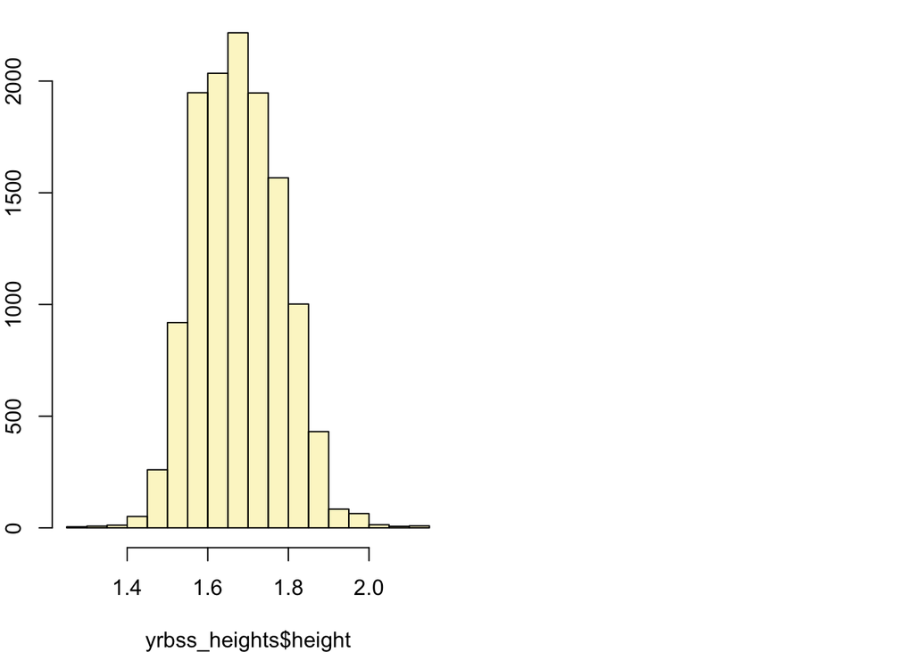

```
## mean = 1.6912 ;  sd = 0.1047 ;  n = 12579
## Standard error = 9e-04
## 95 % Confidence interval = ( 1.6894 , 1.6931 )
```

```r
oilabs::inference(y = height,
                 data = yrbss_heights,
                 null = 0,
                 statistic = "mean",
                 type = "ci",
                 alternative = "twosided",
                 method = "theoretical")
```

```
## Single numerical variable
## n = 12579, y-bar = 1.6912, s = 0.1047
## 95% CI: (1.6894 , 1.6931)
```

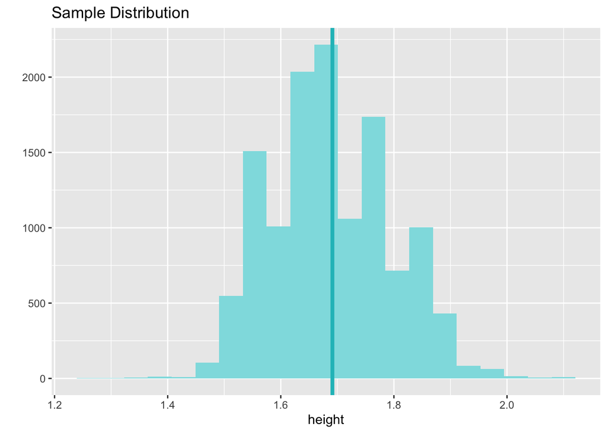

### Exercise 9

The range is smaller at 90% confidence because we’re less confident, which means by reducing the range, the true average is less likely to fall within it

```r
z <- 1.645



yrbss_heights$height %>%
  t.test(conf.level = 0.90)
```

```
##
##  One Sample t-test
##
## data:  .
## t = 1811.7, df = 12578, p-value < 2.2e-16
## alternative hypothesis: true mean is not equal to 0
## 90 percent confidence interval:
##  1.689705 1.692777
## sample estimates:
## mean of x
##  1.691241
```

```r
ciBounds <- yrbss_heights$height %>%
  CI(ci = 0.90)

ciBounds
```

```
##    upper     mean    lower
## 1.692777 1.691241 1.689705
```

```r
meanCIBounds <- yrbss_heights$height %>%
  MeanCI(conf.level = 0.90)

meanCIBounds
```

```
##     mean   lwr.ci   upr.ci
## 1.691241 1.689705 1.692777
```

```r
paste("Upper bound:", ciBounds[[1]])
```

```
## [1] "Upper bound: 1.69277653368189"
```

```r
paste("Lower bound:", ciBounds[[3]])
```

```
## [1] "Lower bound: 1.68970538061972"
```

```r
paste("Interval:", ciBounds[[1]] - ciBounds[[3]])
```

```
## [1] "Interval: 0.00307115306216632"
```

```r
DATA606::inference(y = yrbss_heights$height,
                   type = "ci",
                   est = "mean",
                   alternative = "twosided",
                   method = "theoretical",
                   conflevel = 0.90)
```

```
## Single mean
## Summary statistics:
```

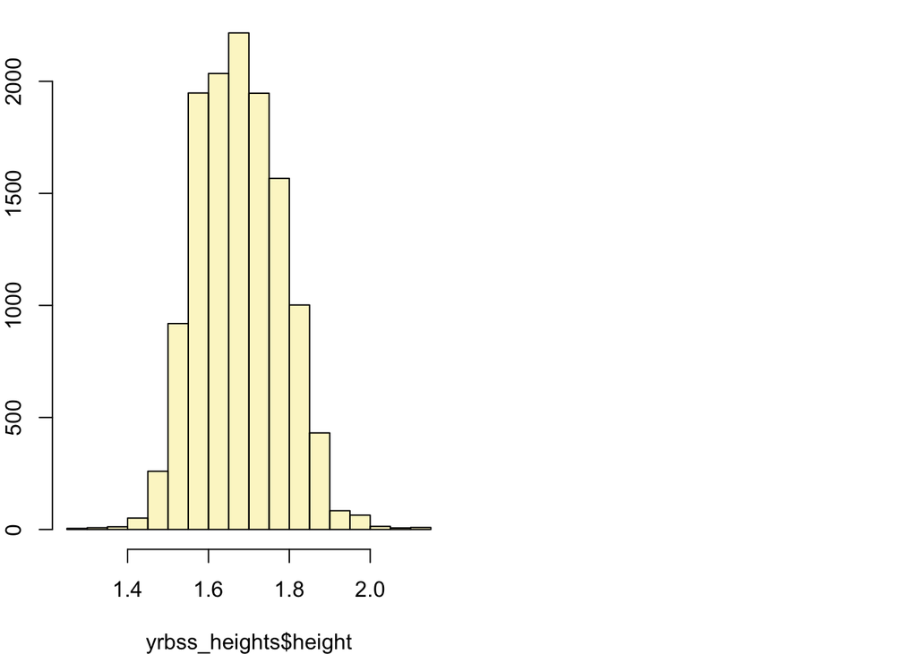

```
## mean = 1.6912 ;  sd = 0.1047 ;  n = 12579
## Standard error = 9e-04
## 90 % Confidence interval = ( 1.6897 , 1.6928 )
```

```r
oilabs::inference(y = height,
                  data = yrbss_heights,
                  null = 0,
                  statistic = "mean",
                  type = "ci",
                  alternative = "twosided",
                  method = "theoretical")
```

```
## Single numerical variable
## n = 12579, y-bar = 1.6912, s = 0.1047
## 95% CI: (1.6894 , 1.6931)
```

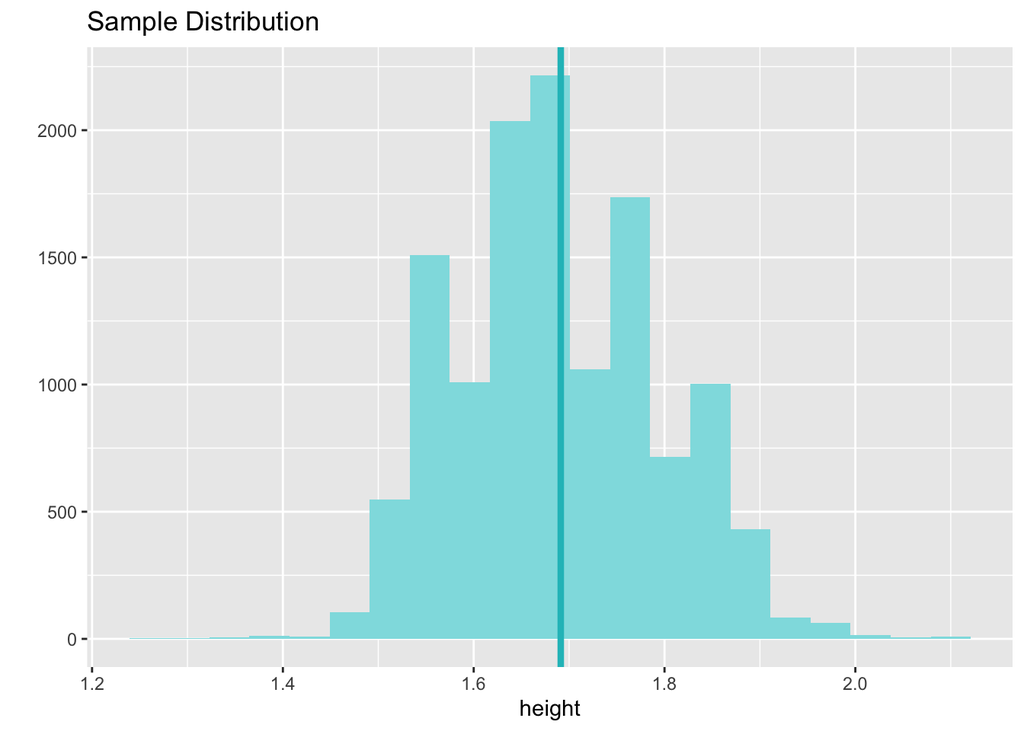

### Exercise 10

H0: There is no correlation between height and number of days worked out in a week  
HA: There is a correlation between height and number of days worked out in a week  
Since the p-value is less than 0.05, we can reject the null hypothesis

```r
yes_physical_3plus_yrbss_heights <- (yrbss_heights %>%
  filter(physical_3plus == yesLabel))

yes_physical_3plus_yrbss_heights$height %>%
  summary
```

```
##    Min. 1st Qu.  Median    Mean 3rd Qu.    Max.
##   1.270   1.630   1.700   1.703   1.780   2.110
```

```r
yes_physical_3plus_yrbss_heights$height %>%
  MeanCI
```

```
##     mean   lwr.ci   upr.ci
## 1.703213 1.700996 1.705430
```

```r
no_physical_3plus_yrbss_heights <- (yrbss_heights %>%
  filter(physical_3plus == noLabel))

no_physical_3plus_yrbss_heights$height %>%
  summary
```

```
##    Min. 1st Qu.  Median    Mean 3rd Qu.    Max.
##   1.270   1.600   1.650   1.666   1.730   2.110
```

```r
no_physical_3plus_yrbss_heights$height %>%
  MeanCI
```

```
##     mean   lwr.ci   upr.ci
## 1.665587 1.662407 1.668767
```

```r
DATA606::inference(y = yrbss_heights$height,
                   x = yrbss_heights$physical_3plus,
                   null = 0,
                   est = "mean",
                   order = c(yesLabel, noLabel),
                   type = "ht",
                   alternative = "twosided",
                   method = "theoretical")
```

```
## Response variable: numerical, Explanatory variable: categorical
## Difference between two means
## Summary statistics:
## n_yes = 8342, mean_yes = 1.7032, sd_yes = 0.1033
## n_no = 4022, mean_no = 1.6656, sd_no = 0.1029
```

```
## Observed difference between means (yes-no) = 0.0376
##
## H0: mu_yes - mu_no = 0
## HA: mu_yes - mu_no != 0
## Standard error = 0.002
## Test statistic: Z =  19.029
## p-value =  0
```

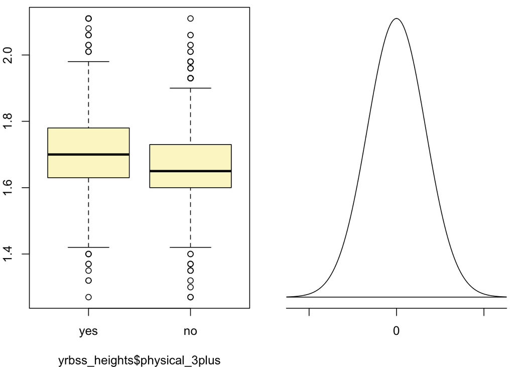

```r
oilabs::inference(y = height,
                  x = physical_3plus,
                  data = yrbss_heights,
                  null = 0,
                  statistic = "mean",
                  order = c(yesLabel, noLabel),
                  type = "ht",
                  alternative = "twosided",
                  method = "theoretical")
```

```
## Response variable: numerical
## Explanatory variable: categorical (2 levels)
## n_yes = 8342, y_bar_yes = 1.7032, s_yes = 0.1033
## n_no = 4022, y_bar_no = 1.6656, s_no = 0.1029
## H0: mu_yes =  mu_no
## HA: mu_yes != mu_no
## t = 19.0293, df = 4021
## p_value = < 0.0001
```

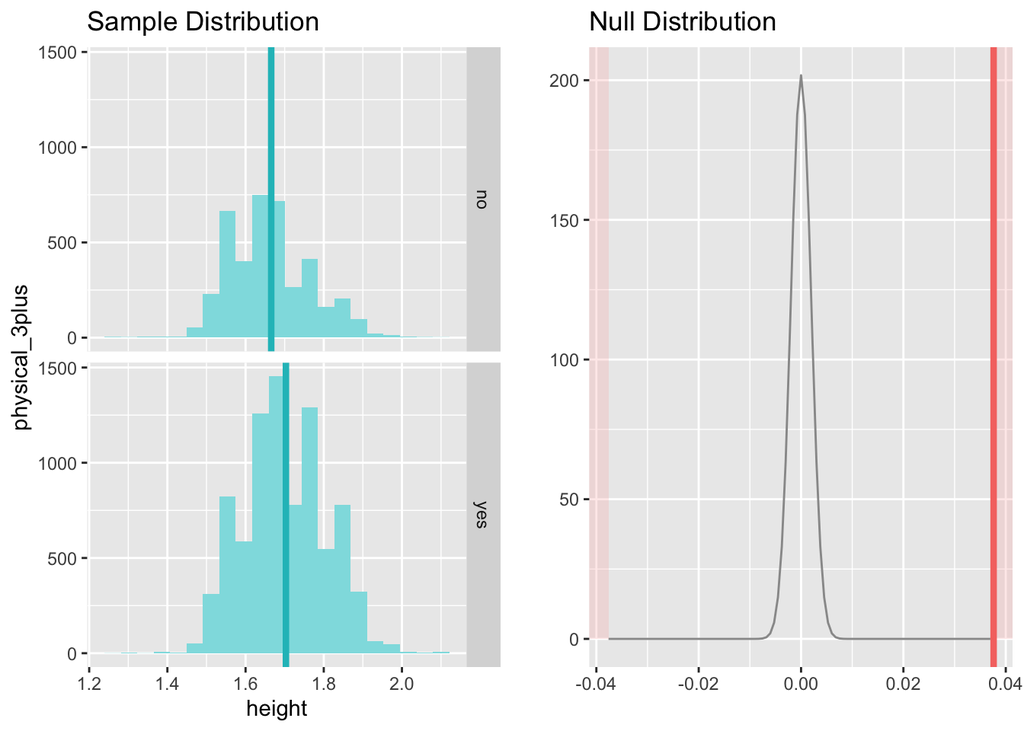

### Exercise 11

There are 8 options for hours_tv_per_school_day (one of which is NA)

```r
yrbss %>%
  group_by(hours_tv_per_school_day) %>%
  dplyr::summarise(n())
```

```
## # A tibble: 8 × 2
##   hours_tv_per_school_day `n()`
##   <chr>                   <int>
## 1 <1                       2168
## 2 1                        1750
## 3 2                        2705
## 4 3                        2139
## 5 4                        1048
## 6 5+                       1595
## 7 do not watch             1840
## 8 <NA>                      338
```

### Exercise 12

H0: There is no correlation between weight and hours of sleep on a school night  
HA: There is a correlation between weight and hours of sleep on a school night  
Since the p-value is less than 0.05, we can reject the null hypothesis

```r
yrbss_weight_school_night_hours_sleep <- yrbss %>%
  filter(!is.na(weight)) %>%
  filter(!is.na(school_night_hours_sleep))



oilabs::inference(y = weight,
                  x = school_night_hours_sleep,
                  data = yrbss_weight_school_night_hours_sleep,
                  null = 0,
                  statistic = "mean",
                  order = c(yesLabel, noLabel),
                  type = "ht",
                  alternative = "greater",
                  method = "theoretical")
```

```
## Response variable: numerical
## Explanatory variable: categorical (7 levels)
## n_<5 = 859, y_bar_<5 = 70.297, s_<5 = 19.4797
## n_10+ = 255, y_bar_10+ = 69.2925, s_10+ = 19.9296
## n_5 = 1378, y_bar_5 = 68.4181, s_5 = 17.4775
## n_6 = 2496, y_bar_6 = 68.3332, s_6 = 17.1255
## n_7 = 3283, y_bar_7 = 67.4346, s_7 = 16.1218
## n_8 = 2505, y_bar_8 = 67.4575, s_8 = 16.5239
## n_9 = 705, y_bar_9 = 65.559, s_9 = 15.8774
##
## ANOVA:
##                             df       Sum_Sq   Mean_Sq      F  p_value
## school_night_hours_sleep     6   11333.0572 1888.8429 6.5813 < 0.0001
## Residuals                11474 3293032.0999  286.9995
## Total                    11480 3304365.1572
##
## Pairwise tests - t tests with pooled SD:
## # A tibble: 21 × 3
##    group1 group2   p.value
##    <chr>  <chr>      <dbl>
##  1 10+    <5     0.406
##  2 5      <5     0.0107
##  3 5      10+    0.449
##  4 6      <5     0.00339
##  5 6      10+    0.389
##  6 6      5      0.881
##  7 7      <5     0.0000105
##  8 7      10+    0.0916
##  9 7      5      0.0705
## 10 7      6      0.0458
## # … with 11 more rows
```

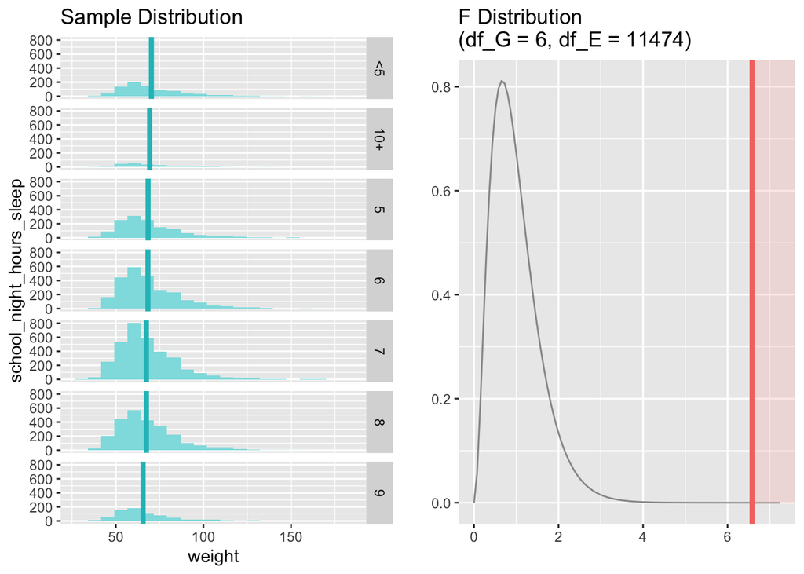